```python
import pandas as pd
import numpy as np
import matplotlib.pyplot as plt
import seaborn as sns
```

# 1. Load the dataset

```python
df = pd.read_csv('Titanic-Dataset.csv')
```

```python
df
```

|  | PassengerId | Survived | Pclass | Name | Sex | Age | SibSp | Parch | Ticket | Fare | Cabin | Embarked |
| --- | --- | --- | --- | --- | --- | --- | --- | --- | --- | --- | --- | --- |
| 0 | 1 | 0 | 3 | Braund, Mr. Owen Harris | male | 22.0 | 1 | 0 | A/5 21171 | 7.2500 | NaN | S |
| 1 | 2 | 1 | 1 | Cumings, Mrs. John Bradley (Florence Briggs Th... | female | 38.0 | 1 | 0 | PC 17599 | 71.2833 | C85 | C |
| 2 | 3 | 1 | 3 | Heikkinen, Miss. Laina | female | 26.0 | 0 | 0 | STON/O2. 3101282 | 7.9250 | NaN | S |
| 3 | 4 | 1 | 1 | Futrelle, Mrs. Jacques Heath (Lily May Peel) | female | 35.0 | 1 | 0 | 113803 | 53.1000 | C123 | S |
| 4 | 5 | 0 | 3 | Allen, Mr. William Henry | male | 35.0 | 0 | 0 | 373450 | 8.0500 | NaN | S |
| ... | ... | ... | ... | ... | ... | ... | ... | ... | ... | ... | ... | ... |
| 886 | 887 | 0 | 2 | Montvila, Rev. Juozas | male | 27.0 | 0 | 0 | 211536 | 13.0000 | NaN | S |
| 887 | 888 | 1 | 1 | Graham, Miss. Margaret Edith | female | 19.0 | 0 | 0 | 112053 | 30.0000 | B42 | S |
| 888 | 889 | 0 | 3 | Johnston, Miss. Catherine Helen "Carrie" | female | NaN | 1 | 2 | W./C. 6607 | 23.4500 | NaN | S |
| 889 | 890 | 1 | 1 | Behr, Mr. Karl Howell | male | 26.0 | 0 | 0 | 111369 | 30.0000 | C148 | C |
| 890 | 891 | 0 | 3 | Dooley, Mr. Patrick | male | 32.0 | 0 | 0 | 370376 | 7.7500 | NaN | Q |

891 rows × 12 columns

# 2. Check for missing values

```python
df.isnull().any()
```

```
PassengerId    False
Survived       False
Pclass         False
Name           False
Sex            False
Age             True
SibSp          False
Parch          False
Ticket         False
Fare           False
Cabin           True
Embarked        True
dtype: bool
```

```python
df['Age'].isnull().value_counts()
```

```
False    714
True     177
Name: Age, dtype: int64
```

```python
df['Cabin'].isnull().value_counts()
```

```
True     687
False    204
Name: Cabin, dtype: int64
```

```python
df['Embarked'].isnull().value_counts()
```

```
False    889
True       2
Name: Embarked, dtype: int64
```

```python
df['Cabin']
```

```
0       NaN
1       C85
2       NaN
3      C123
4       NaN
       ...
886     NaN
887     B42
888     NaN
889    C148
890     NaN
Name: Cabin, Length: 891, dtype: object
```

```python
df['Embarked']
```

```
0      S
1      C
2      S
3      S
4      S
      ..
886    S
887    S
888    S
889    C
890    Q
Name: Embarked, Length: 891, dtype: object
```

### Embarked has only 2 missing values compared to a total of 891. So we will drop the missing values in this column

```python
df['Embarked'].dropna()
```

```
0      S
1      C
2      S
3      S
4      S
      ..
886    S
887    S
888    S
889    C
890    Q
Name: Embarked, Length: 889, dtype: object
```

```python
df['Embarked']
```

```
0      S
1      C
2      S
3      S
4      S
      ..
886    S
887    S
888    S
889    C
890    Q
Name: Embarked, Length: 891, dtype: object
```

```python
df = df.dropna(subset=['Embarked'])
```

```python
df
```

|  | PassengerId | Survived | Pclass | Name | Sex | Age | SibSp | Parch | Ticket | Fare | Cabin | Embarked |
| --- | --- | --- | --- | --- | --- | --- | --- | --- | --- | --- | --- | --- |
| 0 | 1 | 0 | 3 | Braund, Mr. Owen Harris | male | 22.0 | 1 | 0 | A/5 21171 | 7.2500 | NaN | S |
| 1 | 2 | 1 | 1 | Cumings, Mrs. John Bradley (Florence Briggs Th... | female | 38.0 | 1 | 0 | PC 17599 | 71.2833 | C85 | C |
| 2 | 3 | 1 | 3 | Heikkinen, Miss. Laina | female | 26.0 | 0 | 0 | STON/O2. 3101282 | 7.9250 | NaN | S |
| 3 | 4 | 1 | 1 | Futrelle, Mrs. Jacques Heath (Lily May Peel) | female | 35.0 | 1 | 0 | 113803 | 53.1000 | C123 | S |
| 4 | 5 | 0 | 3 | Allen, Mr. William Henry | male | 35.0 | 0 | 0 | 373450 | 8.0500 | NaN | S |
| ... | ... | ... | ... | ... | ... | ... | ... | ... | ... | ... | ... | ... |
| 886 | 887 | 0 | 2 | Montvila, Rev. Juozas | male | 27.0 | 0 | 0 | 211536 | 13.0000 | NaN | S |
| 887 | 888 | 1 | 1 | Graham, Miss. Margaret Edith | female | 19.0 | 0 | 0 | 112053 | 30.0000 | B42 | S |
| 888 | 889 | 0 | 3 | Johnston, Miss. Catherine Helen "Carrie" | female | NaN | 1 | 2 | W./C. 6607 | 23.4500 | NaN | S |
| 889 | 890 | 1 | 1 | Behr, Mr. Karl Howell | male | 26.0 | 0 | 0 | 111369 | 30.0000 | C148 | C |
| 890 | 891 | 0 | 3 | Dooley, Mr. Patrick | male | 32.0 | 0 | 0 | 370376 | 7.7500 | NaN | Q |

889 rows × 12 columns

### Now we will impute the age column with KNN method

```python
from sklearn.impute import KNNImputer
```

```python
age = np.array([df['Age']])
imputer = KNNImputer(n_neighbors=5)
df['Age']=imputer.fit_transform(pd.DataFrame(df['Age']))
```

```python
df['Age']
```

```
0      22.000000
1      38.000000
2      26.000000
3      35.000000
4      35.000000
         ...
886    27.000000
887    19.000000
888    29.642093
889    26.000000
890    32.000000
Name: Age, Length: 889, dtype: float64
```

### Now we try to impute the cabin category

```python
df['Cabin'].isnull().value_counts()
```

```
True     687
False    202
Name: Cabin, dtype: int64
```

```python
df['Cabin'].unique()
```

```
array([nan, 'C85', 'C123', 'E46', 'G6', 'C103', 'D56', 'A6',
       'C23 C25 C27', 'B78', 'D33', 'B30', 'C52', 'C83', 'F33', 'F G73',
       'E31', 'A5', 'D10 D12', 'D26', 'C110', 'B58 B60', 'E101', 'F E69',
       'D47', 'B86', 'F2', 'C2', 'E33', 'B19', 'A7', 'C49', 'F4', 'A32',
       'B4', 'B80', 'A31', 'D36', 'D15', 'C93', 'C78', 'D35', 'C87',
       'B77', 'E67', 'B94', 'C125', 'C99', 'C118', 'D7', 'A19', 'B49',
       'D', 'C22 C26', 'C106', 'C65', 'E36', 'C54', 'B57 B59 B63 B66',
       'C7', 'E34', 'C32', 'B18', 'C124', 'C91', 'E40', 'T', 'C128',
       'D37', 'B35', 'E50', 'C82', 'B96 B98', 'E10', 'E44', 'A34', 'C104',
       'C111', 'C92', 'E38', 'D21', 'E12', 'E63', 'A14', 'B37', 'C30',
       'D20', 'B79', 'E25', 'D46', 'B73', 'C95', 'B38', 'B39', 'B22',
       'C86', 'C70', 'A16', 'C101', 'C68', 'A10', 'E68', 'B41', 'A20',
       'D19', 'D50', 'D9', 'A23', 'B50', 'A26', 'D48', 'E58', 'C126',
       'B71', 'B51 B53 B55', 'D49', 'B5', 'B20', 'F G63', 'C62 C64',
       'E24', 'C90', 'C45', 'E8', 'B101', 'D45', 'C46', 'D30', 'E121',
       'D11', 'E77', 'F38', 'B3', 'D6', 'B82 B84', 'D17', 'A36', 'B102',
       'B69', 'E49', 'C47', 'D28', 'E17', 'A24', 'C50', 'B42', 'C148'],
      dtype=object)
```

```python
df = df.drop(['Cabin'],axis=1)
df
```

|  | PassengerId | Survived | Pclass | Name | Sex | Age | SibSp | Parch | Ticket | Fare | Embarked |
| --- | --- | --- | --- | --- | --- | --- | --- | --- | --- | --- | --- |
| 0 | 1 | 0 | 3 | Braund, Mr. Owen Harris | male | 22.000000 | 1 | 0 | A/5 21171 | 7.2500 | S |
| 1 | 2 | 1 | 1 | Cumings, Mrs. John Bradley (Florence Briggs Th... | female | 38.000000 | 1 | 0 | PC 17599 | 71.2833 | C |
| 2 | 3 | 1 | 3 | Heikkinen, Miss. Laina | female | 26.000000 | 0 | 0 | STON/O2. 3101282 | 7.9250 | S |
| 3 | 4 | 1 | 1 | Futrelle, Mrs. Jacques Heath (Lily May Peel) | female | 35.000000 | 1 | 0 | 113803 | 53.1000 | S |
| 4 | 5 | 0 | 3 | Allen, Mr. William Henry | male | 35.000000 | 0 | 0 | 373450 | 8.0500 | S |
| ... | ... | ... | ... | ... | ... | ... | ... | ... | ... | ... | ... |
| 886 | 887 | 0 | 2 | Montvila, Rev. Juozas | male | 27.000000 | 0 | 0 | 211536 | 13.0000 | S |
| 887 | 888 | 1 | 1 | Graham, Miss. Margaret Edith | female | 19.000000 | 0 | 0 | 112053 | 30.0000 | S |
| 888 | 889 | 0 | 3 | Johnston, Miss. Catherine Helen "Carrie" | female | 29.642093 | 1 | 2 | W./C. 6607 | 23.4500 | S |
| 889 | 890 | 1 | 1 | Behr, Mr. Karl Howell | male | 26.000000 | 0 | 0 | 111369 | 30.0000 | C |
| 890 | 891 | 0 | 3 | Dooley, Mr. Patrick | male | 32.000000 | 0 | 0 | 370376 | 7.7500 | Q |

889 rows × 11 columns

```python
df.isnull().any()
```

```
PassengerId    False
Survived       False
Pclass         False
Name           False
Sex            False
Age            False
SibSp          False
Parch          False
Ticket         False
Fare           False
Embarked       False
dtype: bool
```

### Now there are zero mssing values in the dataset!

# 3. Check for outliers

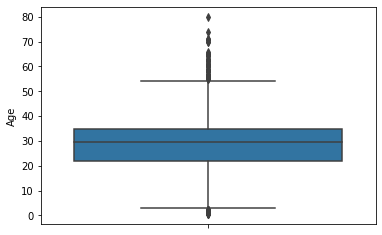

```python
sns.boxplot(y='Age',data=df)
```

### As this boxplot shows, there are too many outliers for us to delete. Let's keep them.

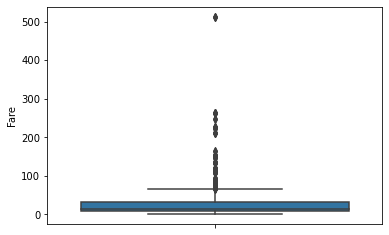

```python
sns.boxplot(y='Fare',data=df)
```

### The same applies to the ticket fare.

# 4. Splitting Dependent and Independent Variables

### SURVIVED is the dependent variable

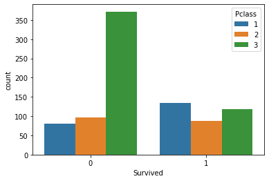

```python
sns.countplot(x='Survived',hue='Pclass',data=df)
```

### Third-class passengers make a disproportionate amount of the death toll. Pclass is an independent variable.

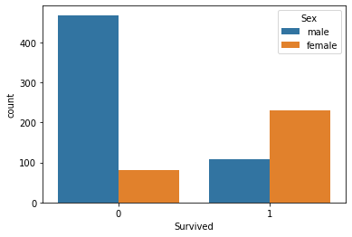

```python
sns.countplot(x='Survived',hue='Sex',data=df)
```

### The majority of survivors are female. This is because the lifeboats prioritised women and children over men. Hence gender qualifies as an independent variable that influences the chance of survival.

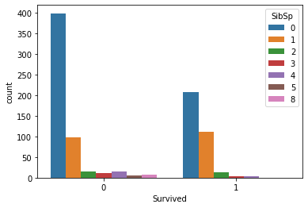

```python
sns.countplot(x='Survived',hue='SibSp',data=df)
```

### SibSp refers to the number of siblings or spouses of the passenger who boarded the Titanic. The data patterns are similar for the living and the dead, so SibSp does not have enough influence on the chance of survival.

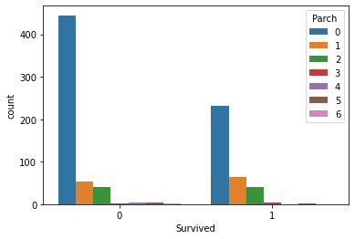

```python
sns.countplot(x='Survived',hue='Parch',data=df)
```

### Similar data results apply for Parch, the number of the passenger's parents and children aboard the Titanic. Hence we discard Parch like SibSp

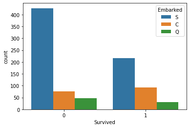

```python
sns.countplot(x='Survived',hue='Embarked',data=df)
```

### And it's the same story for embarkment

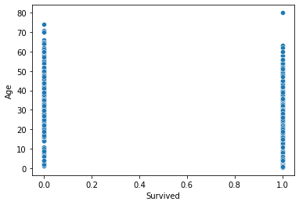

```python
sns.scatterplot(x='Survived',y='Age',data=df)
```

### Survivors' ages skew lower than the casualties'. We encounter an outlier in the form of an 80-year-old survivor.

```python
df.loc[df['Age']==80]
```

|  | PassengerId | Survived | Pclass | Name | Sex | Age | SibSp | Parch | Ticket | Fare | Embarked |
| --- | --- | --- | --- | --- | --- | --- | --- | --- | --- | --- | --- |
| 630 | 631 | 1 | 1 | Barkworth, Mr. Algernon Henry Wilson | male | 80.0 | 0 | 0 | 27042 | 30.0 | S |

### The outlier's id is 630. We can delete this outlier to increase the accuracy of our model.

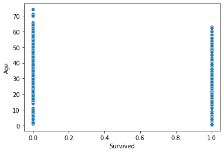

```python
df = df.drop([630])
sns.scatterplot(x='Survived',y='Age',data=df)
```

### We've removed the outlier. Now we can declare Age as an independent variable.

### PassengerId, Name and Ticket do not qualify as independent variables because they are unique values.

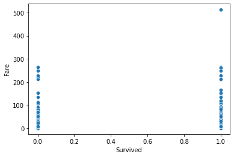

```python
sns.scatterplot(x='Survived',y='Fare',data=df)
```

## DEPENDENT VARIABLE: Survived

## INDEPENDENT VARIABLES: Pclass, Age, Gender

```python
y = df.iloc[:,1] #Dependent variable
y
```

```
0      0
1      1
2      1
3      1
4      0
      ..
886    0
887    1
888    0
889    1
890    0
Name: Survived, Length: 888, dtype: int64
```

```python
x = df.drop(['PassengerId','Survived','Name','SibSp','Parch','Ticket','Fare','Embarked'],axis=1)
x
```

|  | Pclass | Sex | Age |
| --- | --- | --- | --- |
| 0 | 3 | male | 22.000000 |
| 1 | 1 | female | 38.000000 |
| 2 | 3 | female | 26.000000 |
| 3 | 1 | female | 35.000000 |
| 4 | 3 | male | 35.000000 |
| ... | ... | ... | ... |
| 886 | 2 | male | 27.000000 |
| 887 | 1 | female | 19.000000 |
| 888 | 3 | female | 29.642093 |
| 889 | 1 | male | 26.000000 |
| 890 | 3 | male | 32.000000 |

888 rows × 3 columns

# 5. Encode the categorical data

### Sex is the only independent variable that is not numeric. We can use a simple label encoder since this category has only 2 unique values.

```python
from sklearn.preprocessing import LabelEncoder
```

```python
le = LabelEncoder()
```

```python
x['Sex'] = le.fit_transform(x['Sex'])
```

```python
x
```

|  | Pclass | Sex | Age |
| --- | --- | --- | --- |
| 0 | 3 | 1 | 22.000000 |
| 1 | 1 | 0 | 38.000000 |
| 2 | 3 | 0 | 26.000000 |
| 3 | 1 | 0 | 35.000000 |
| 4 | 3 | 1 | 35.000000 |
| ... | ... | ... | ... |
| 886 | 2 | 1 | 27.000000 |
| 887 | 1 | 0 | 19.000000 |
| 888 | 3 | 0 | 29.642093 |
| 889 | 1 | 1 | 26.000000 |
| 890 | 3 | 1 | 32.000000 |

888 rows × 3 columns

### Now our whole datasets are numeric.

# 6. Feature Scaling

```python
from sklearn.preprocessing import MinMaxScaler
```

```python
ms = MinMaxScaler()
```

```python
x = pd.DataFrame(ms.fit_transform(x),columns = x.columns)
```

```python
x
```

|  | Pclass | Sex | Age |
| --- | --- | --- | --- |
| 0 | 1.0 | 1.0 | 0.293286 |
| 1 | 0.0 | 0.0 | 0.510737 |
| 2 | 1.0 | 0.0 | 0.347649 |
| 3 | 0.0 | 0.0 | 0.469965 |
| 4 | 1.0 | 1.0 | 0.469965 |
| ... | ... | ... | ... |
| 883 | 0.5 | 1.0 | 0.361239 |
| 884 | 0.0 | 0.0 | 0.252514 |
| 885 | 1.0 | 0.0 | 0.397147 |
| 886 | 0.0 | 1.0 | 0.347649 |
| 887 | 1.0 | 1.0 | 0.429193 |

888 rows × 3 columns

# 7. Split the data into training and testing set

```python
from sklearn.model_selection import train_test_split
```

```python
x_train,x_test,y_train,y_test = train_test_split(x,y,test_size=0.2,random_state=0)
```

```python
x_train
```

|  | Pclass | Sex | Age |
| --- | --- | --- | --- |
| 363 | 1.0 | 1.0 | 0.397147 |
| 255 | 0.0 | 0.0 | 0.397147 |
| 476 | 1.0 | 1.0 | 0.388421 |
| 271 | 0.5 | 0.0 | 0.551509 |
| 553 | 1.0 | 0.0 | 0.293286 |
| ... | ... | ... | ... |
| 835 | 1.0 | 1.0 | 0.429193 |
| 192 | 0.5 | 1.0 | 0.035064 |
| 629 | 1.0 | 1.0 | 0.687415 |
| 559 | 1.0 | 1.0 | 0.397147 |
| 684 | 1.0 | 1.0 | 0.184561 |

710 rows × 3 columns

```python
x_test
```

|  | Pclass | Sex | Age |
| --- | --- | --- | --- |
| 14 | 1.0 | 0.0 | 0.184561 |
| 158 | 1.0 | 1.0 | 0.397147 |
| 762 | 1.0 | 1.0 | 0.211742 |
| 740 | 0.0 | 0.0 | 0.279696 |
| 482 | 1.0 | 0.0 | 0.850503 |
| ... | ... | ... | ... |
| 834 | 1.0 | 1.0 | 0.397147 |
| 672 | 0.5 | 1.0 | 0.397147 |
| 181 | 1.0 | 1.0 | 0.116608 |
| 631 | 0.0 | 1.0 | 0.397147 |
| 140 | 1.0 | 0.0 | 0.293286 |

178 rows × 3 columns

```python
y_train
```

```
364    0
256    1
477    0
272    1
554    1
      ..
838    1
193    1
631    0
560    0
686    0
Name: Survived, Length: 710, dtype: int64
```

```python
y_test
```

```
14     0
159    0
764    0
742    1
483    1
      ..
837    0
674    0
182    0
633    0
141    1
Name: Survived, Length: 178, dtype: int64
```